Universidad Nacional Autónoma de México - Licenciatura en ciencias genómicas

Introducción a Ciencia de Datos 2021 - Tarea 1

**Salvador González Juárez**

Todas las gráficas deben tener título, nombres de los ejes y categorías modificados y colores, además de ser generadas con la librería ggplot2. Sube el archivo .Rmd y el HTML o PDF a cursos.

### 1. Abre el archivo “cardiovascular_disease.csv” encontrado en cursos en R (todos los descriptores del dataset se encuentran en el archivo llamado “attributes.txt”).

```r
# Llamar a la libreria requerida para generar las graficas
library(ggplot2)

# Leemos el archivo que vamos a visualizar
setwd("/home/salvador/Documentos/Licenciatura_Ciencias_Genomicas/Cuarto_Semestre/Ciencia_Datos/Tarea_1")
data <- read.csv("cardiovascular_disease.csv")

# Imprimimos las primeras lineas de los datos para saber que tipo de informacion hay
head(data)
```

```
##   id age_days age_year gender height weight ap_hi ap_lo cholesterol gluc smoke
## 1  0    18393 50.39178      2    168     62   110    80           1    1     0
## 2  1    20228 55.41918      1    156     85   140    90           3    1     0
## 3  2    18857 51.66301      1    165     64   130    70           3    1     0
## 4  3    17623 48.28219      2    169     82   150   100           1    1     0
## 5  4    17474 47.87397      1    156     56   100    60           1    1     0
## 6  8    21914 60.03836      1    151     67   120    80           2    2     0
##   alco active cardio
## 1    0      1      0
## 2    0      1      1
## 3    0      0      1
## 4    0      1      1
## 5    0      0      0
## 6    0      0      0
```

### 2. Realiza una gráfica de barras con el número de pacientes que se encuentran en cada grupo discreto de la variable colesterol.

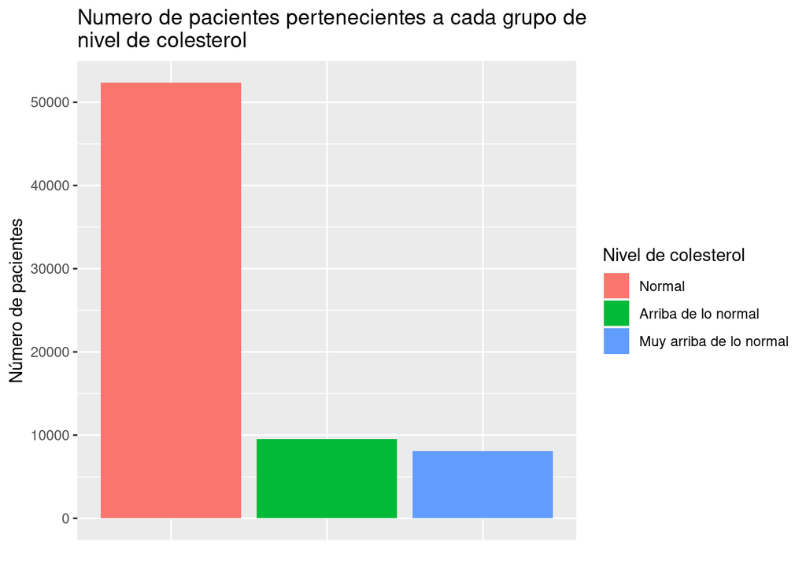

```r
# Realizar un cambio en el tipo de variable para que se interpretada de la forma correcta
data$cholesterol <- as.character(data$cholesterol)

# Sacar las cuentas de pacientes para cada grupo discreto de la variable colesterol
counts <- as.data.frame(table(data$cholesterol))

# Convertir la matriz en un dataframe y hacr que los nombres de las filas sean una columna
counts$cholesterol <- rownames(counts)

# Dibujar la grafica de barras
ggplot(counts, aes(x = Var1, y = Freq, fill = Var1)) +
  geom_bar(stat = "identity") +
  theme(axis.ticks.x = element_blank(), axis.text.x=element_blank()) +
  scale_fill_discrete(name = "Nivel de colesterol", labels = c("Normal", "Arriba de lo normal", "Muy arriba de lo normal")) +
  labs(title = "Numero de pacientes pertenecientes a cada grupo de\nnivel de colesterol", x = "", y = "Número de pacientes")
```

### 3. Realiza una gráfica de barras con el número de pacientes que se encuentran en cada grupo discreto de la variable colesterol agrupada por ausencia o presencia de una enfermedad cardiovascular. ¿Encuentras alguna asociación entre ambas variables?

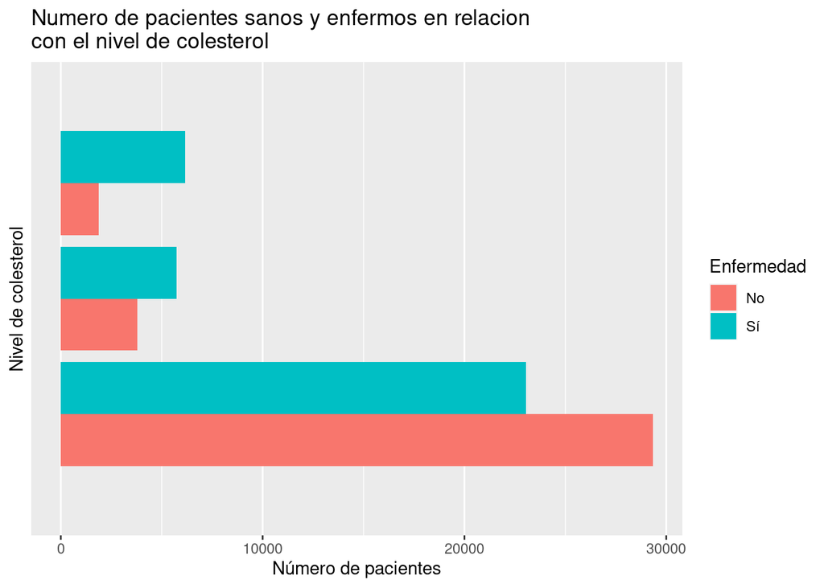

```
La gráfica nos indica que aquellas personas con un nivel de colesterol por encima de lo normal son más propensos a padecer alguna enfermedad cardiovascular, en comparación con aquellos individuos que poseen un nivel de colesterol normal.
```

```r
# Sacar las cuentas de pacientes para cada grupo de nivel de colesterol y enfermedad
counts2 <- as.data.frame(tapply(data$cholesterol,
                  list(data$cholesterol, data$cardio),
                  table))
# Hacemos que los nombres de las filas sean una columna
counts2$cholesterol <- rownames(counts2)

# Transformar el dataframe al formato long
counts2 <- reshape(counts2,
        direction = "long",
        varying = list(names(counts2)[1:2]),
        v.names = "Counts",
        idvar = "Cholesterol",
        timevar = "Disease",
        times = c("0", "1"))
row.names(counts2) <- NULL

# Dibujar la gráfica de barras lado a lado
ggplot(counts2, aes(x = Cholesterol, y = Counts, fill = Disease)) +
  geom_bar(stat = "identity", position=position_dodge()) +
  coord_flip() +
  scale_fill_discrete(name = "Enfermedad", labels = c("No", "Sí")) +
  scale_x_discrete(labels = c("Normal", "Arriba de lo normal", "Muy arriba de lo normal")) +
  labs(title = "Numero de pacientes sanos y enfermos en relacion\ncon el nivel de colesterol", x = "Nivel de colesterol", y = "Número de pacientes")
```

### 4. Realiza un histograma de la variable estatura y coloca una gráfica de densidad encima.

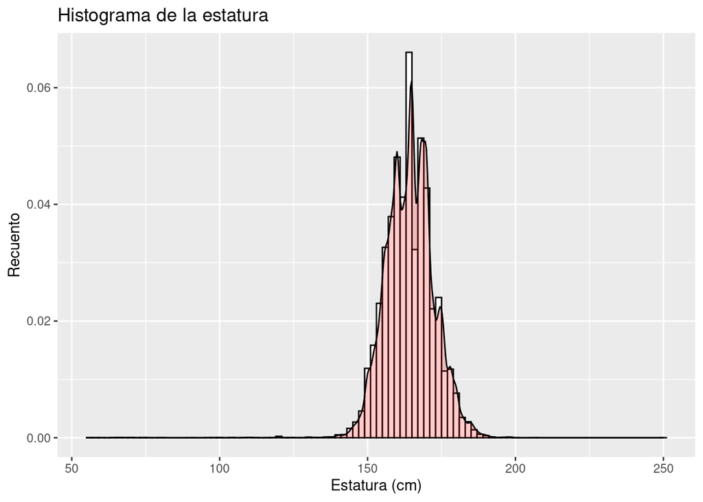

```r
# Dibujar una grafica de tipo histograma con densidad
ggplot(data, aes(x = height)) +
  geom_histogram(aes(y=..density..), binwidth = 2, color = "black", fill = "white") +
  geom_density(alpha = 0.2, fill = "red") +
  labs(title = "Histograma de la estatura", x = "Estatura (cm)", y = "Recuento")
```

### 5. Realiza un histograma de la variable estatura agrupada por género. ¿Encuentras alguna asociación entre ambas variables?

Como ultimas modificaciones, para hacer nuestra grafica mas estetica, podemos cambiar la leyenda utilizando scale_color_discrete().

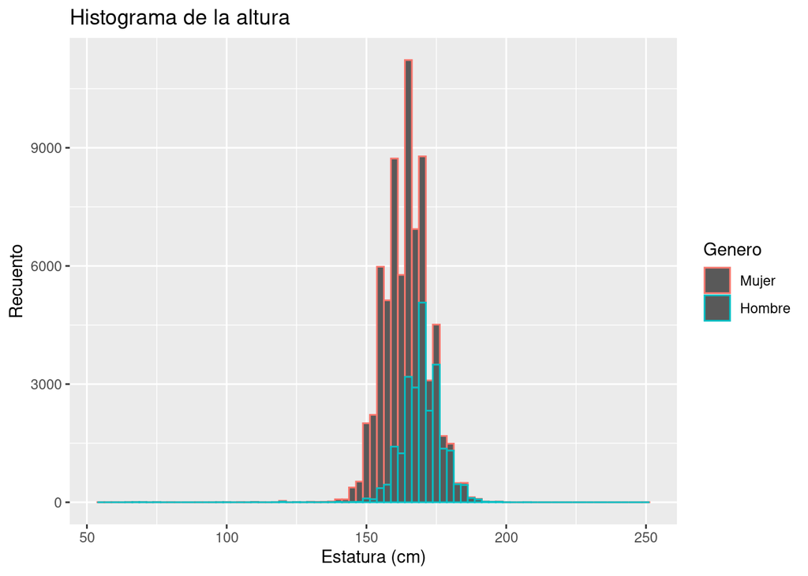

```
El promedio de la estatura de los hombres es mayor al promedio de la estatura de las mujeres. Esto se refleja en la distribución que tiene cada genero.
```

```r
# Sobreponer otra variable en el histograma de densidad
data$gender <- as.character(data$gender)
ggplot(data, aes(x = height, color = gender)) +
  geom_histogram(binwidth = 2.5) +
  labs(title = "Histograma de la altura", x = "Estatura (cm)", y = "Recuento") +
  scale_color_discrete(name = "Genero", labels = c("Mujer", "Hombre"))
```

### 6. Realiza una gráfica de dispersión con las variables tensión arterial sistólica y tensión arterial diastólica (limita el eje x a 250 y el eje y a 200). Coloca una línea de regresión encima. ¿Encuentras alguna asociación entre las variables?

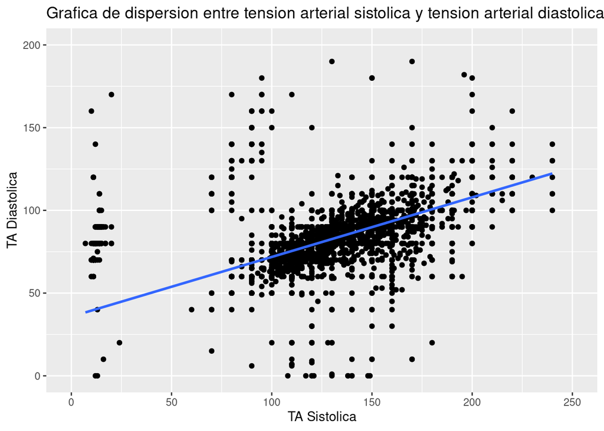

```
La regresión lineal indica que la TA Diastólica aumenta de forma proporcional cuando la TA Sistólica se incrementa.
```

```r
# Dibujar una grafica de dispersion, incluyendo regresion lineal
ggplot(data, aes(x = ap_hi, y = ap_lo)) +
  geom_point() + geom_smooth(method = lm) +
  xlim(0,250) + ylim(0,200) +
  labs(title = "Grafica de dispersion entre tension arterial sistolica y tension arterial diastolica", x = "TA Sistolica", y = "TA Diastolica")
```

### 7. Realiza una gráfica de dispersión con las variables tensión arterial sistólica y tensión arterial diastólica (limita el eje x a 250 y el eje y a 200), agrupada por la presencia o ausencia de una enfermedad cardiovascular. ¿Qué relación crees que existe entre estas tres variables?

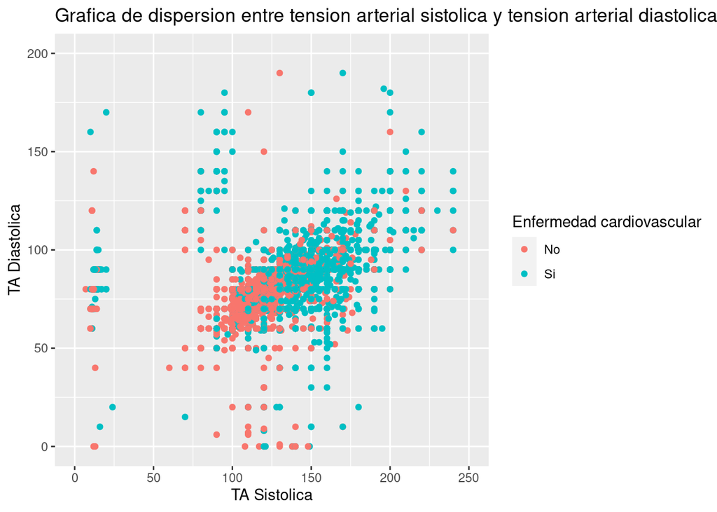

```
Aquellos pacientes que tienen una TA Sistólica más alta (lo cual significa también una TA Diastólica más alta) son más propensos a padecer enfermedades cardiovasculares.
```

```r
# Sobreponer otra variable en la grafica de dispersion
data$cardio <- as.character(data$cardio)
ggplot(data, aes(x = ap_hi, y = ap_lo, color = cardio)) +
  geom_point() +
  xlim(0,250) + ylim(0,200) +
  labs(title = "Grafica de dispersion entre tension arterial sistolica y tension arterial diastolica", x = "TA Sistolica", y = "TA Diastolica") +
  scale_color_discrete(name = "Enfermedad cardiovascular", labels = c("No", "Si"))
```

### 8. Realiza un boxplot con la variable peso y la variable de enfermedad cardiovascular. ¿Qué puedes deducir sobre el peso de los pacientes con enfermedades cardiovasculares?

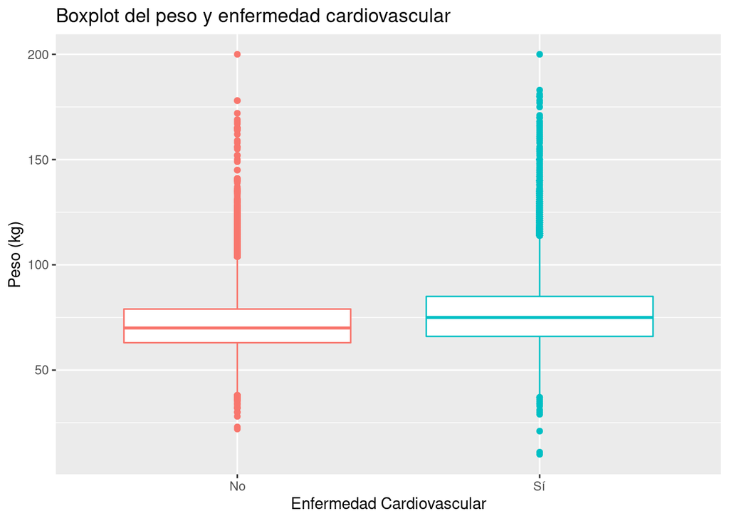

```
Los pacientes que padecen enfermedad cardiovascular poseen en promedio un peso ligeramente mayor al de aquellos individuos que no presentan enfremedad cardiovascular.
```

```r
# Dibujar un boxplot que separa por categoria de enfermedad cardiovascular
ggplot(data, aes(x = cardio, y = weight, color = cardio)) +
  geom_boxplot() +
  theme(legend.position = "none") +
  labs(title = "Boxplot del peso y enfermedad cardiovascular", x = "Enfermedad Cardiovascular", y = "Peso (kg)") +
  scale_x_discrete(labels = c("No", "Sí"))
```

### 9. Realiza un boxplot con la variable peso y la variable de enfermedad cardiovascular, agrupadas por la variable “fumar”. ¿Qué relación existe entre las tres variables?

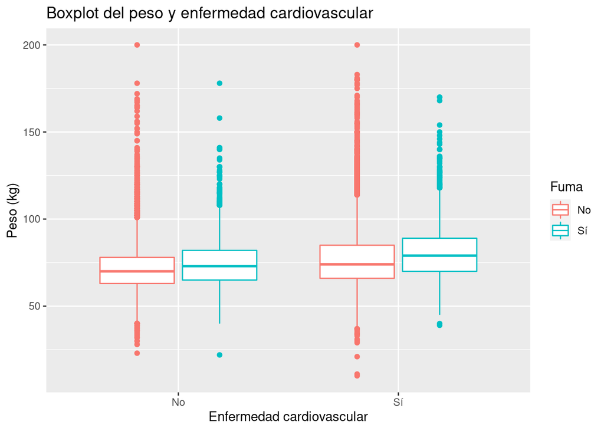

```
Aquellos pacientes que fuman y tienen enfermedad cardiovascular tienen en promedio un peso mayor a los individuos que no fuman y son sanos.
```

```r
# Agregar una variable mas a la grafica de boxplot
data$smoke <- as.character(data$smoke)
ggplot(data, aes(x = cardio, y = weight, color = smoke)) +
  geom_boxplot() +
  labs(title = "Boxplot del peso y enfermedad cardiovascular", x = "Enfermedad cardiovascular", y = "Peso (kg)") +
  scale_color_discrete(name = "Fuma", labels = c("No", "Sí")) +
  scale_x_discrete(labels = c("No", "Sí"))
```

### 10. Realiza un heatmap de la edad en años, la presión arterial sistólica, la presión arterial diastólica, la estatura y el peso, contra los grupos obtenidos de las combinaciones entre las variables colesterol y enfermedad cardiovascular (debes obtener un heatmap de 6x5).

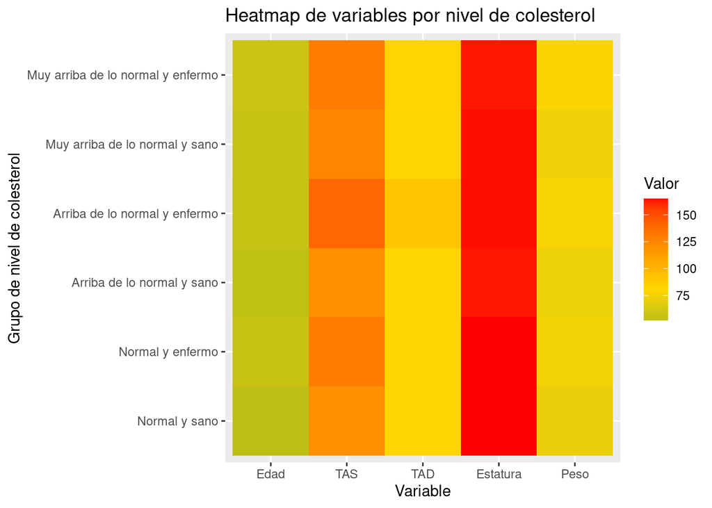

```r
# Seleccionar algunas variables cuantitativas para representar en el heatmap
data$age_year <- round(data$age_year, 0)
hm_data <- aggregate(data[,c(3, 5, 6, 7, 8)],
          by = list(data$cholesterol, data$cardio),
          median, na.rm = T)

# Transformar al formato long
hm_data$Group.1 <- paste(hm_data$Group.1, hm_data$Group.2, sep = ":")
hm_data <- reshape(hm_data,
                   direction = "long",
                   varying = list(names(hm_data)[3:7]),
                   v.names = "Value",
                   idvar = "Group.1",
                   timevar = "Variable",
                   times = colnames(hm_data)[3:7])
row.names(hm_data) <- NULL

# Dibujar la grafica de heatmap
ggplot(hm_data, aes(x = Variable, y = Group.1, fill = Value)) +
  geom_tile() +
  scale_fill_gradient2(low = "forestgreen", high = "red", mid = "gold", midpoint = median(hm_data$Value)) +
  labs(title = "Heatmap de variables por nivel de colesterol", fill = "Valor", y = "Grupo de nivel de colesterol", x = "Variable") +
  scale_y_discrete(labels = c("Normal y sano", "Normal y enfermo", "Arriba de lo normal y sano", "Arriba de lo normal y enfermo", "Muy arriba de lo normal y sano", "Muy arriba de lo normal y enfermo")) +
  scale_x_discrete(labels = c("Edad", "TAS", "TAD", "Estatura", "Peso"))
```